# Exploring the MTPL1 Frequency Dataset

Author

Mick Cooney mickcooney@gmail.com

Published

August 18, 2023

This workbook was created using the ‘dataexpks’ template:

https://github.com/DublinLearningGroup/dataexpks

# 1 Introduction

This workbook performs the basic data exploration of the dataset.

```r
dataexp_level_exclusion_threshold <- 100

dataexp_cat_level_count <- 40
dataexp_hist_bins_count <- 50
```

# 2 Load Data

First we load the dataset.

```r
### _TEMPLATE_
### Data is loaded into dataset rawdata_tbl here

### We may wish to set column typs
#data_col_types <- cols(
#  VAR1 = col_character(),
#  VAR2 = col_date(),
#  VAR3 = col_number()
#)

### Data is loaded into dataset rawdata_tbl here
#rawdata_tbl <- read_csv(DATAFILE,
#                        locale    = locale(),
#                        col_types = data_col_types,
#                        progress  = FALSE
#                       )
rawdata_tbl <- read_rds("data/modelling1_data_tbl.rds") |> select(-sev_data)

glimpse(rawdata_tbl)
```

```
Rows: 413,169
Columns: 14
$ policy_id      <chr> "1", "2", "3", "4", "5", "6", "7", "8", "9", "10", "11"…
$ exposure       <dbl> 0.09, 0.84, 0.52, 0.45, 0.15, 0.75, 0.81, 0.05, 0.76, 0…
$ power          <fct> g, g, f, f, g, g, d, d, d, i, f, f, e, e, e, e, e, e, i…
$ car_age        <int> 0, 0, 2, 2, 0, 0, 1, 0, 9, 0, 2, 2, 0, 0, 0, 0, 0, 0, 0…
$ driver_age     <int> 46, 46, 38, 38, 41, 41, 27, 27, 23, 44, 32, 32, 33, 33,…
$ brand          <fct> "Japanese (except Nissan) or Korean", "Japanese (except…
$ gas            <fct> Diesel, Diesel, Regular, Regular, Diesel, Diesel, Regul…
$ region         <fct> Aquitaine, Aquitaine, Nord-Pas-de-Calais, Nord-Pas-de-C…
$ density        <int> 76, 76, 3003, 3003, 60, 60, 695, 695, 7887, 27000, 23, …
$ claim_total    <int> 0, 0, 0, 0, 0, 0, 0, 0, 0, 0, 0, 0, 0, 0, 0, 0, 0, 0, 0…
$ claim_count    <int> 0, 0, 0, 0, 0, 0, 0, 0, 0, 0, 0, 0, 0, 0, 0, 0, 0, 0, 0…
$ cat_driver_age <fct> 43-74, 43-74, 27-42, 27-42, 27-42, 27-42, 27-42, 27-42,…
$ cat_car_age    <fct> 0-1, 0-1, 2-4, 2-4, 0-1, 0-1, 0-1, 0-1, 5-15, 0-1, 2-4,…
$ cat_density    <fct> 41-200, 41-200, 501-4500, 501-4500, 41-200, 41-200, 501…
```

## 2.1 Perform Quick Data Cleaning

```r
### _TEMPLATE_
### Do simple datatype transforms and save output in data_tbl
data_tbl <- rawdata_tbl %>% set_colnames(names(.) %>% to_snake_case())

glimpse(data_tbl)
```

```
Rows: 413,169
Columns: 14
$ policy_id      <chr> "1", "2", "3", "4", "5", "6", "7", "8", "9", "10", "11"…
$ exposure       <dbl> 0.09, 0.84, 0.52, 0.45, 0.15, 0.75, 0.81, 0.05, 0.76, 0…
$ power          <fct> g, g, f, f, g, g, d, d, d, i, f, f, e, e, e, e, e, e, i…
$ car_age        <int> 0, 0, 2, 2, 0, 0, 1, 0, 9, 0, 2, 2, 0, 0, 0, 0, 0, 0, 0…
$ driver_age     <int> 46, 46, 38, 38, 41, 41, 27, 27, 23, 44, 32, 32, 33, 33,…
$ brand          <fct> "Japanese (except Nissan) or Korean", "Japanese (except…
$ gas            <fct> Diesel, Diesel, Regular, Regular, Diesel, Diesel, Regul…
$ region         <fct> Aquitaine, Aquitaine, Nord-Pas-de-Calais, Nord-Pas-de-C…
$ density        <int> 76, 76, 3003, 3003, 60, 60, 695, 695, 7887, 27000, 23, …
$ claim_total    <int> 0, 0, 0, 0, 0, 0, 0, 0, 0, 0, 0, 0, 0, 0, 0, 0, 0, 0, 0…
$ claim_count    <int> 0, 0, 0, 0, 0, 0, 0, 0, 0, 0, 0, 0, 0, 0, 0, 0, 0, 0, 0…
$ cat_driver_age <fct> 43-74, 43-74, 27-42, 27-42, 27-42, 27-42, 27-42, 27-42,…
$ cat_car_age    <fct> 0-1, 0-1, 2-4, 2-4, 0-1, 0-1, 0-1, 0-1, 5-15, 0-1, 2-4,…
$ cat_density    <fct> 41-200, 41-200, 501-4500, 501-4500, 41-200, 41-200, 501…
```

## 2.2 Create Derived Variables

```r
data_tbl <- data_tbl

glimpse(data_tbl)
```

```
Rows: 413,169
Columns: 14
$ policy_id      <chr> "1", "2", "3", "4", "5", "6", "7", "8", "9", "10", "11"…
$ exposure       <dbl> 0.09, 0.84, 0.52, 0.45, 0.15, 0.75, 0.81, 0.05, 0.76, 0…
$ power          <fct> g, g, f, f, g, g, d, d, d, i, f, f, e, e, e, e, e, e, i…
$ car_age        <int> 0, 0, 2, 2, 0, 0, 1, 0, 9, 0, 2, 2, 0, 0, 0, 0, 0, 0, 0…
$ driver_age     <int> 46, 46, 38, 38, 41, 41, 27, 27, 23, 44, 32, 32, 33, 33,…
$ brand          <fct> "Japanese (except Nissan) or Korean", "Japanese (except…
$ gas            <fct> Diesel, Diesel, Regular, Regular, Diesel, Diesel, Regul…
$ region         <fct> Aquitaine, Aquitaine, Nord-Pas-de-Calais, Nord-Pas-de-C…
$ density        <int> 76, 76, 3003, 3003, 60, 60, 695, 695, 7887, 27000, 23, …
$ claim_total    <int> 0, 0, 0, 0, 0, 0, 0, 0, 0, 0, 0, 0, 0, 0, 0, 0, 0, 0, 0…
$ claim_count    <int> 0, 0, 0, 0, 0, 0, 0, 0, 0, 0, 0, 0, 0, 0, 0, 0, 0, 0, 0…
$ cat_driver_age <fct> 43-74, 43-74, 27-42, 27-42, 27-42, 27-42, 27-42, 27-42,…
$ cat_car_age    <fct> 0-1, 0-1, 2-4, 2-4, 0-1, 0-1, 0-1, 0-1, 5-15, 0-1, 2-4,…
$ cat_density    <fct> 41-200, 41-200, 501-4500, 501-4500, 41-200, 41-200, 501…
```

# 3 Perform Basic Checks on Data

We now want to look at some very high level checks on the data, and we leverage some of the functionality provided by `DataExplorer`.

## 3.1 Create High-Level Visualisations

We first want to look at a visualisation of some high-level summarys of the meta-data on this dataset. This gives us a quick view of the categorical and 1numeric values in the dataset, as well as the proportions of missing values.

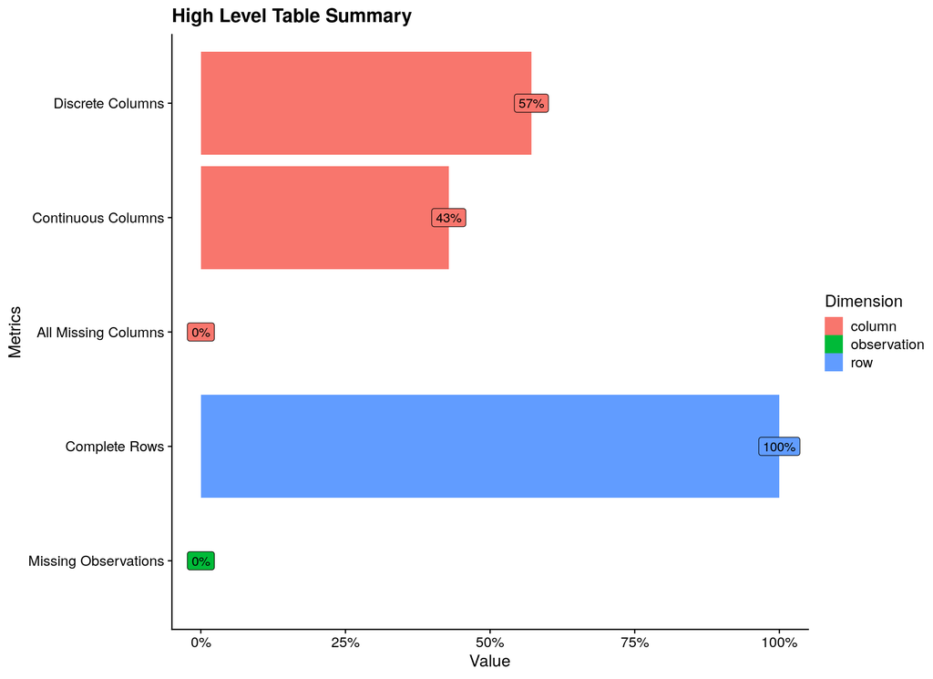

```r
data_tbl %>%
  plot_intro(
    title   = "High Level Table Summary",
    ggtheme = theme_cowplot()
    )
```